# Overview

Electricity has always been at the heart of residents’ daily life, industrial production, and transportation.

A reliable prediction of electricity price can help people and businesses to plan ahead, avoid unnecessary cost and maximize output.

This project aims to collect data on electricity generation, fuel consumption and weather conditions of state of Virginia to form a model to predict future electricity price in Virginia.

# Methods

### Methods consider using

According to the Energy Informatio Administration, fuel, transportation, power plant cost, weather condition and regulation have great impact on electricity price.

This project will employ both traditional machine learning techniques such as linear regression, KNN and random forest and Time Series methods to generate a plausible model for predicting future electricity price and gain insights from the models.

### Methods used to date

### traditional machine learning:

Linear Model

KNN with K tuning param

Decision Tree regression with the Max Depth Param

The Bagging decision tree regression model

Random forest with the N Estimators and max_depth tuning param

### Time Seires model:

ARIMA

# Preliminary Results

```python
search.best_params_
```

```
{'model': RandomForestRegressor(max_depth=5, n_estimators=300, random_state=0),
 'model__max_depth': 5,
 'model__n_estimators': 300,
 'model__random_state': 0}
```

```python
pred_y = search.predict(test_X)

m.r2_score(test_y,pred_y)
```

```
0.8956119467795509
```

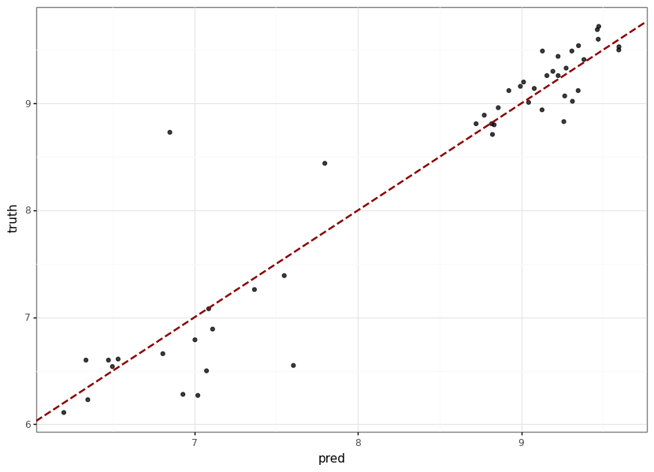

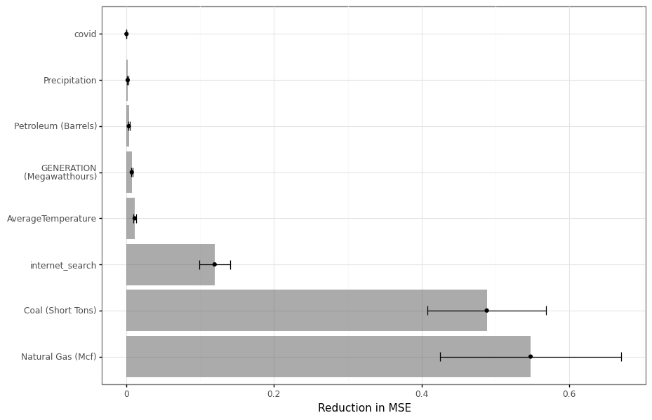

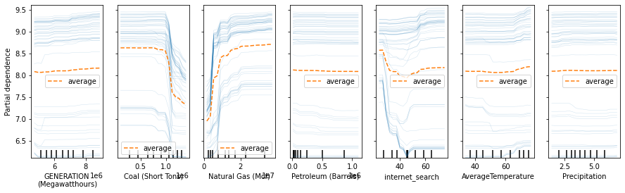

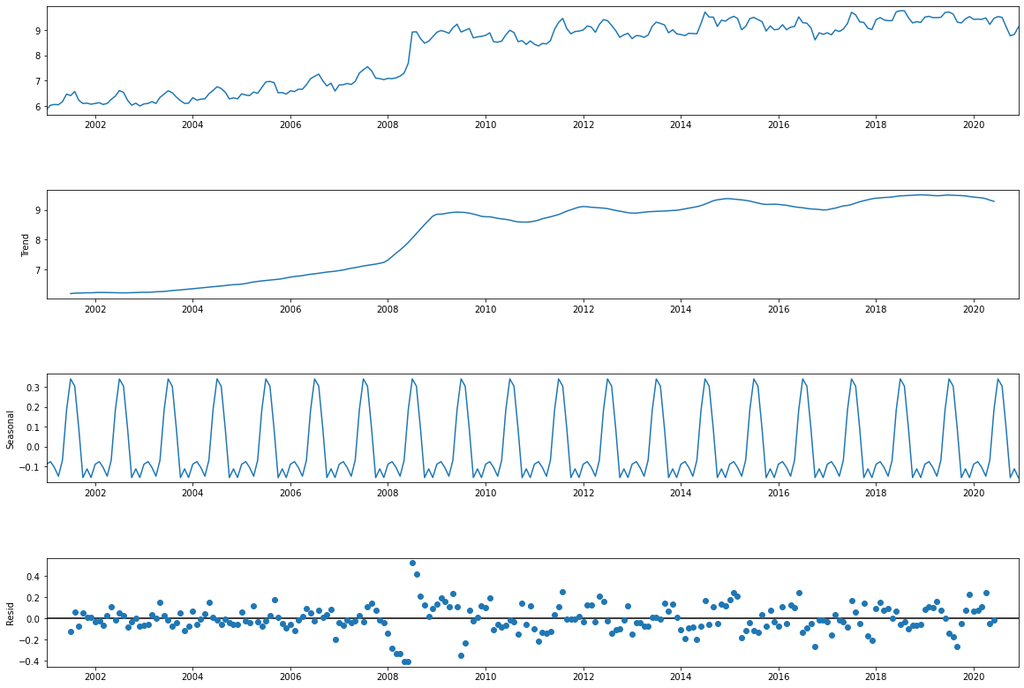

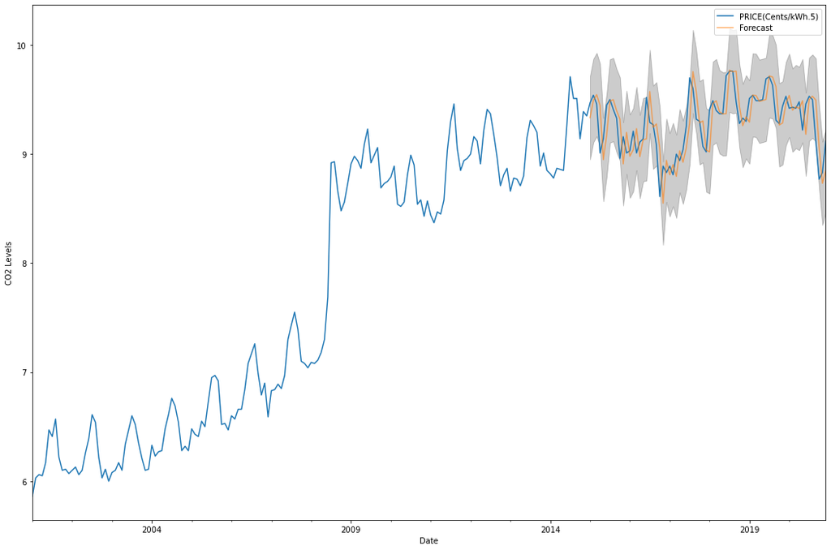

# Future efforts

Boost up the importance of weather conditions

Add the prices of coal and gas

Add another dummy variable to control for the financial crisis